# Sumário

```python
import pandas as pd
import numpy as np
from scipy import stats
import seaborn as sns
import matplotlib.pyplot as plt
from decimal import Decimal

import warnings
warnings.filterwarnings('ignore')
```

```python
df_salarios = pd.read_csv('dados/dados_tratados.csv').drop('Unnamed: 0', axis=1)
df_b3 = pd.read_csv('dados/b3_stocks_1994_2020.csv')
df_b3['datetime'] = pd.to_datetime(df_b3['datetime'])
```

# Conceito

Uma variável aleatória é dita continua se seus valores forem definidos sobre um espaço amostral $\Omega$ e assumindo qualquer valor em um intervalo de números reais, isto é, para cada $a < b$, qualquer valor $x$ entre os valores $a$ e $b$ for possível.

Vamos a um exemplo para ficar fácil a compreensão. Vamos ver o menor e maior salário em dólares da nossa base de salários na área de dados.

```python
print(df_salarios['salario_em_dolares'].min(), df_salarios['salario_em_dolares'].max())
```

```
5132 450000
```

Logo, sabemos que qualquer profissional de dados, baseado nessa pesquisa, pode ganhar qualquer salário entre 5.132,00 dólares e 450.000,00 dólares, logo, podemos dizer que: $$\{x \in \mathbb{R} : US\$5.132,00 \leq x \leq US\$450.000,00\}$$

Voltando ao nosso exemplo, vemos que podemos ter diversos valores de salários possíveis e se formos ver a probabilidade de cada um, essa probabilidade tenderá a 0, o que não faz muito sentido falar em probabilidade para um determinado valor. Entretanto, podemos determinar a probabilidade de que $X$ esteja compreendido entre dois valores quaisquer. Se dividirmos nosso intervalo por 4, vamos ter a seguinte probabilidade:

$$P(US\$5.132,00 \leq x \leq US\$116.349,00) = \frac{1}{4}$$

Do mesmo modo, podemos criar intervalos maiores ou menores, e sempre conseguimos calcular a probabilidade de um trabalhador da área de dados ganhar um salário dentro desse intervalo. Então, podemos pegar dois salários quaisquer ($a$ e $b$), tais que $(US\$5.132,00 \leq a \leq b \leq US\$116.349,00)$, a probabilidade de $X \in [a, b)$ é:

$$P(a \leq X \leq b) = \frac{b-a}{450000 - 5132} = \frac{b-a}{444868}$$

,

Logo se considerarmos $a = US\$5.132,00$ e $b = US\$116.349,00$, temos:

$$P(US\$5.132,00 \leq x \leq US\$116.349,00) = \frac{116349 - 5132}{444868} = \frac{111217}{444868} = \frac{1}{4}$$

Vamos criar um histograma para este caso:

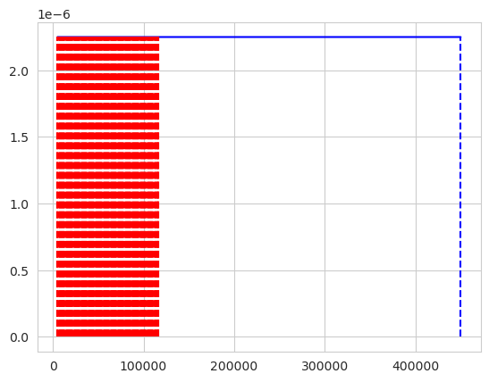

```python
x = list(range(5132, 450000, 1))
probabilidade = list(np.linspace(1/444868, 1/444868, 444868))
probabilidade2 = list(np.linspace(0, 1/444868, 100))
final = list(np.linspace(450000, 450000, 100))
a = list(np.linspace(5132, 5132, 100))
b = list(np.linspace(116349, 116349, 100))
with sns.axes_style("whitegrid"):
    plt.plot(x, probabilidade, 'b')
    plt.plot(final, probabilidade2, 'b--')
    plt.plot(a, probabilidade2, 'r--')
    plt.plot(b, probabilidade2, 'r--')
    for i in list(np.linspace(5132, 116349, 100)):
        valor = list(np.linspace(i, i, 100))
        plt.plot(valor, probabilidade2, 'r--')
    plt.show()
```

De modo generalizado, podemos dizer que:

$$\text{f(x)} = \begin{cases} 0, \text{se x < 0}\\ \frac{1}{444868}, \text{se } US\$5.132,00 \leq x \leq US\$450.000,00\\ 0, \text{se x} > US\$450.000,00 \end{cases}$$

Nós temos no histograma criado a parte hachurada em vermelho, que representa a probabilidade que calculamos. Logo a probabilidade pode ser dada pela área correspondente ao intervalo $a$ e $b$ (intervalo vermelho). Então, matematicamente, podemos expressar nossa função como:

$$P(a \leq X \leq b) = \int_a^b f(x)dx = \int_a^b \frac{1}{444868}dx = \frac{b-a}{444868}$$

A integral definida de uma função entre dois pontos determina a área sob a curva representativa da função, compreendida sobre esses dois pontos.

A função $f(x)$ é chamada de função de densidade de probabilidade (f.d.p) da variável aleatória $X$.

# Valor médio de uma variável aleatória contínua

Por enquanto temos que a probabilidade da variável pertencer a um intervalo de dois valores é:

$$P(a \leq X \leq b) = \int_a^b f(x)dx$$

Vamos criar um novo gráfico.

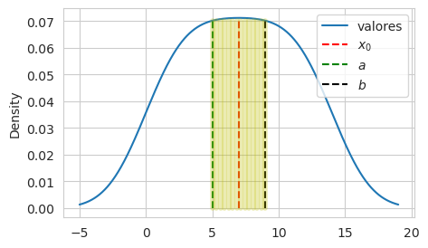

```python
valor_medio_y = list(np.linspace(0, 0.07, 14))
valor_medio_x = list(np.linspace(7, 7, 14))
a_x = list(np.linspace(5, 5, 14))
a_y = list(np.linspace(0, 0.07, 14))
b_x = list(np.linspace(9, 9, 14))
b_y = list(np.linspace(0, 0.07, 14))
platicurtica = [1, 1, 3, 3, 5, 5, 7, 7, 9, 9, 11, 11, 13, 13]
df_assimetrico_direita = pd.DataFrame({'valores': platicurtica})

with sns.axes_style("whitegrid"):
    df_assimetrico_direita.plot(kind='kde', figsize=(5, 3))
    plt.plot(valor_medio_x, valor_medio_y, 'r--', label='$x_0$')
    plt.plot(a_x, a_y, 'g--', label='$a$')
    plt.plot(b_x, b_y, 'k--', label='$b$')

    valor_rachurado = list(np.linspace(0.07, 0.07, 14))

    for index, i in enumerate(list(np.linspace(5, 9, 14))):
        y = valor_rachurado[index]
        valor_y = list(np.linspace(0, y, 14))
        valor = list(np.linspace(i, i, 14))
        plt.plot(valor, valor_y, 'y-', linewidth=4, alpha=0.3)
    plt.legend()
    plt.show()
```

Vamos considerar $a = 5$ e $b = 9$, teremos então que $h = b - a$, e consideremos $x_0$ o ponto médio do intervalo $[a, b]$, logo será 7. Sabendo que a a área do retângulo pode ser dada por $\text{área da base} \times \text{altura}$, teremos que:

- $\text{área da base} = h$
- $\text{altura} = f(x_0)$

Então, considerando que uma variável aleatória $Y_n$, assumindo os valores $x_1,...,x_n$, temos as probabilidades:

$$p_i = P(Y_n = x_i) \approx f(x_i)h$$

Lembrando que a definição de esperança matemática, temos:

$$E(Y_n) = \sum_{i=1}^n x_ip_i \approx \sum_{i=1}^{n}x_i f(x_i) h$$

Temos a aproximação da esperança $E(X)$ para variáveis aleatórios continuas.

Para determinar $E(X)$ com maior precisão, podemos diminuir a amplitude $h$ (diminuindo a área da base. Isso fará com que tenhamos mais retângulos, logo aumentando nosso $n$). Então fazendo o $h$ tender a 0, logo teremos:

$$E(X) = \lim_{n \to \infty}E(Y_n) = \lim_{n \to \infty}\sum_{i=1}^{n}x_i f(x_i) h$$

**OBS.:** Segue um gif demonstrando o que seria o $h$ tendendo a 0 ($h \to 0$)

[figure not shown]

Se o limite existe, definimos a integral $x f(x)$ entre A e B:

$$E(X) = \int_A^B xf(x)dx$$

Para nosso exemplo nós temos:

$$E(X) = \int_A^B xf(x)dx $$$$E(X) = \int_{5132}^{450000} x \frac{1}{444868}dx$$$$E(X) = \frac{x²}{2} f(b) - \frac{x²}{2} f(a)$$$$E(X)= \frac{450000²}{2} \frac{1}{444868} - \frac{5132²}{2} \frac{1}{444868}$$$$E(X) = 227595,6 - 29,6 = 227566$$

Como a função $f(x)$ é sempre não negativa, podemos escrever a esperança como:

$$E(X) = \int_{-\infty}^{\infty}xf(x)dx$$

A variância segue o mesmo princípio da esperança, logo temos:

$$\text{Var(X)} = E[(X - E(X))²] = \int_{-\infty}^{\infty}(x - E(X))^2xf(x)dx $$

# Função de distribuição acumulada

Dada uma variável aleatória $X$ com função densidade de probabilidade $f(x)$, podemos definir a sua função de distribuição acumulada, $F(x)$:

$$F(X) = p(X \leq x), -\infty < x < +\infty$$

usando o conceito de integral, temos:

$$F(x) = \int_{-\infty}^{X}f(t)dt$$

para todo x real.

Vamos ver um exemplo.

Se $f(x) = 2x$, para $0 \leq x \leq 1$ e $0$ fora desse intervalo, então temos:

$$F(x) = \begin{cases} 0, & \text{se x} < 0 \\ \int_{0}^{x}2tdt = x², & \text{se 0} \leq x < 1 \\ \int_{0}^{1}2tdt + \int_{1}^{x}0dt = 1, & \text{se x} \geq 1\\ \end{cases}$$

Com esse exemplo, conseguimos perceber que:

1. $\lim_{x \to -\infty F(X) = 0}$
2. $\lim_{x \to +\infty F(X) = 1}$

O gráfico da função de distribuição acumulada é:

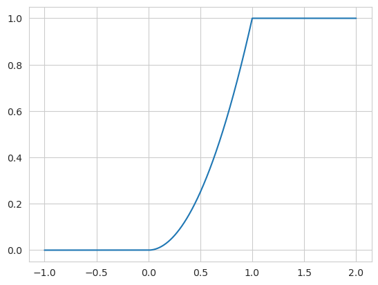

```python
def grafico_distribuicao_acumulada(array):
    lista = []
    for x in array:
        if x <= 0.0:
            resultado = 0
            lista.append(resultado)
        elif x > 1.0:
            resultado = 1
            lista.append(resultado)
        else:
            resultado = x ** 2
            lista.append(resultado)
    return lista

with sns.axes_style("whitegrid"):
    x = list(np.linspace(-1, 2, 1000))
    y = grafico_distribuicao_acumulada(x)
    plt.plot(x, y)
```

# Distribuições contínuas de probabilidade

## Distribuição Uniforme

A distribuição uniforme é o modelo mais simples para variáveis aleatórias contínuas. É definida como:

**Definição**: A variável aleatória X tem distribuição uniforme no intervalo $[\alpha, \beta]$ se sua função de densidade de probabilidade é dada por:

$$f(x, \alpha, \beta) = \begin{cases} \frac{1}{\beta - \alpha}, & \text{se }\alpha \leq x \leq \beta \\ 0, & \text{caso contrário}\\ \end{cases}$$

O gráfico de sua distribuição é:

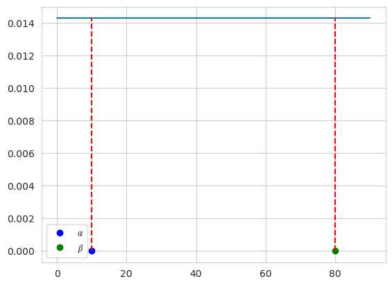

```python
def distribuicao_uniforme(array, alpha, beta):
    y = []
    for i in array:
        resultado = 1/(beta-alpha)
        y.append(resultado)
    return y

x = list(np.linspace(0, 90, 1000))
y = distribuicao_uniforme(x, 10, 80)
beta_x = np.linspace(80, 80, 1000)
beta_y = np.linspace(0, y[0], 1000)
alpha_x = np.linspace(10, 10, 1000)
alpha_y = np.linspace(0, y[0], 1000)

with sns.axes_style("whitegrid"):
    plt.plot(x, y)
    plt.plot(10, 0, 'bo', label='$𝛼$')
    plt.plot(80, 0, 'go', label='$𝛽$')
    plt.plot(beta_x, beta_y, 'r--')
    plt.plot(alpha_x, alpha_y, 'r--')
    plt.legend()
    plt.show()
```

Sua esperança matemática é:

$$E(X) = \frac{\alpha + \beta}{2}$$

Sua variância é:

$$\text{Var(X)} = \frac{(\beta - \alpha)²}{12}$$

E sua função de distribuição acumulada é:

$$F(X) = P(X \leq x) = \int_{-\infty}^{x}f(x)dx = \begin{cases} 0, & \text{se }x < \alpha\\ \frac{x - \alpha}{\beta - \alpha}, & \text{se } \alpha \leq x \leq \beta\\ 1, & \text{se } x \geq \beta \\ \end{cases}$$

O gráfico da distribuição acumulada é:

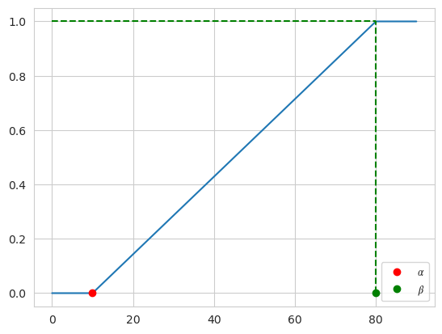

```python
def grafico_distribuicao_acumulada_uniforme(array, alpha, beta):
    lista = []
    for x in array:
        if x < alpha:
            resultado = 0
            lista.append(resultado)
        elif x >= beta:
            resultado = 1
            lista.append(resultado)
        else:
            resultado = (x-alpha)/(beta-alpha)
            lista.append(resultado)
    return lista

x = list(np.linspace(0, 90, 1000))
y = grafico_distribuicao_acumulada_uniforme(x, 10, 80)
beta_x = np.linspace(80, 80, 1000)
beta_y = np.linspace(0, 1, 1000)
beta_x2 = np.linspace(0, 80, 1000)
beta_y2 = np.linspace(1, 1, 1000)

with sns.axes_style("whitegrid"):
    plt.plot(x, y)
    plt.plot(10, 0, 'ro', label='$𝛼$')
    plt.plot(80, 0, 'go', label='$𝛽$')
    plt.plot(beta_x, beta_y, 'g--')
    plt.plot(beta_x2, beta_y2, 'g--')
    plt.legend()
    plt.show()
```

Quando a variável aleatória tiver uma distribuição uniforme no intervalo $[\alpha, \beta]$, usaremos a seguinte notação:

$$X \sim u(\alpha, \beta)$$

**Exemplo**:

Vamos supor que um jogador, em uma partida de futebol faça um gol. Qual a probabilidade desse gol sair nos primeiros 15 minutos?

Sabendo que o tempo é medido em uma escala contínua, a probabilidade do gol é igual a razão do intervalo escolhido sobre a duração da partida, logo:

$$P(0 \leq X \leq 15) = \frac{15 - 0}{90 - 0} = \frac{15}{90} = \frac{1}{6} = 0,166$$

Então temos uma probabilidade de 16,6% de o jogador fazer um gol nesse intervalo.

## Distribuição normal

Está é a distribuição mais famosa, sendo um modelo fundamental em probabilidades e inferência estatística. Sua definição é:

**Definição**: Dizemos que uma variável aleatória $X$ tem distribuição normal com parâmetros $\mu$ e $\sigma²$, onde $\mu$ é a média, que varia entre: $-\infty < \mu <+\infty$, e $\sigma^2$ é a variância, que varia entre $0 <\sigma^2 < +\infty$, se sua densidade é dada por:

$$f(x, \mu, \sigma²) = \frac{1}{\sigma\sqrt{2\pi}}\cdot e^{\frac{-(x-\mu)²}{2\sigma²}}$$

Onde:

- O valor de $x$ pode variar entre: $-\infty < x <+\infty$

O gráfico de sua distribuição é:

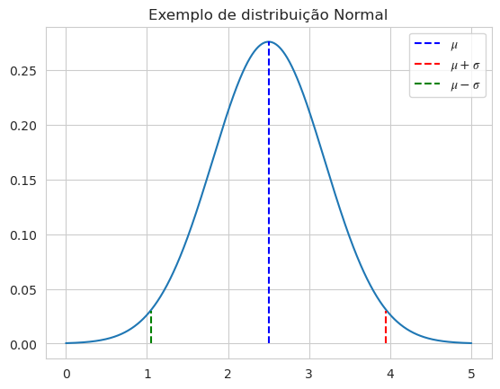

```python
def distribuicao_normal(valores):
    y = []
    media = sum(valores) / len(valores)
    variancia = sum((valores - media)**2)/ (len(valores) - 1)
    for valor in valores:
        multiplicador = np.exp(-((valor - media)**2) / 2 * variancia)
        resultado = (1/(np.sqrt(variancia * 2 * np.pi))) * multiplicador
        y.append(resultado)
    return y

x = list(np.linspace(0, 5, 1000))
media = sum(x) / len(x)
desvio_padrao = np.sqrt(sum((x - media)**2)/ (len(x) - 1))
y = distribuicao_normal(x)

media_x = np.linspace(media, media, 1000)
media_y = np.linspace(0, max(y), 1000)
media_mais_desvio_padrao_x = np.linspace(media + desvio_padrao, media + desvio_padrao, 1000)
media_menos_desvio_padrao_x = np.linspace(media - desvio_padrao, media - desvio_padrao, 1000)
desvio_padrao_y = np.linspace(0, 0.03, 1000)

with sns.axes_style("whitegrid"):
    plt.plot(x, y)
    plt.plot(media_x, media_y, 'b--', label='$𝜇$')
    plt.plot(media_mais_desvio_padrao_x, desvio_padrao_y, 'r--', label='$𝜇+𝜎$')
    plt.plot(media_menos_desvio_padrao_x, desvio_padrao_y, 'g--', label='$𝜇-𝜎$')
    plt.legend()
    plt.title('Exemplo de distribuição Normal')
    plt.show()
```

Sua esperança matemática é:

$$E(X) = \mu$$

Sua variância é:

$$\text{Var(X)} = \sigma² $$

Conseguimos ver com o gráfico que $f(x, \mu, \sigma²) \to 0$, quando $x \to \pm \infty$

Quando a variável aleatória tiver uma distribuição normal, usaremos a seguinte notação:

$$X \sim N(\mu, \sigma²)$$

Quando $\mu = 0$ e $\sigma^2 = 1$, temos uma distribuição padrão. Para essa distribuição, a função de densidade é:

$$\phi(Z) = \frac{1}{\sigma\sqrt{2\pi}}\cdot e^{\frac{z²}{2}}$$

Onde:

- o valor de $z$ varia entre: $-\infty < z < +\infty$

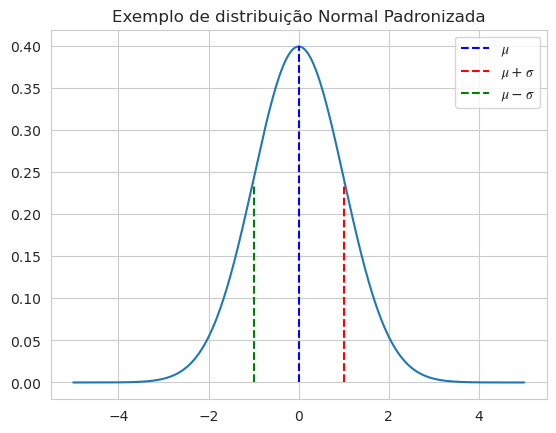

```python
def distribuicao_normal_padronizada(valores):
    y = []
    media = 0
    variancia = 1
    for valor in valores:
        multiplicador = np.exp(-((valor - media)**2) / 2 * variancia)
        resultado = (1/(np.sqrt(variancia * 2 * np.pi))) * multiplicador
        y.append(resultado)
    return y

x = list(np.linspace(-5, 5, 1000))
media = 0
desvio_padrao = 1
y = distribuicao_normal_padronizada(x)

media_x = np.linspace(media, media, 1000)
media_y = np.linspace(0, max(y), 1000)
media_mais_desvio_padrao_x = np.linspace(media + desvio_padrao, media + desvio_padrao, 1000)
media_menos_desvio_padrao_x = np.linspace(media - desvio_padrao, media - desvio_padrao, 1000)
desvio_padrao_y = np.linspace(0, 0.237, 1000)

with sns.axes_style("whitegrid"):
    plt.plot(x, y)
    plt.plot(media_x, media_y, 'b--', label='$𝜇$')
    plt.plot(media_mais_desvio_padrao_x, desvio_padrao_y, 'r--', label='$𝜇+𝜎$')
    plt.plot(media_menos_desvio_padrao_x, desvio_padrao_y, 'g--', label='$𝜇-𝜎$')
    plt.legend()
    plt.title('Exemplo de distribuição Normal Padronizada')
    plt.show()
```

Se $X \sim N(\mu, \sigma²)$, então a variável aleatória definida por $Z = \frac{X - \mu}{\sigma}$ terá média $0$ e variância $1$.

Essa transformação é fundamental para calcularmos as probabilidades relativas a uma distribuição normal qualquer.

A função de distribuição acumulada é dada por:

$$\int_{-\infty}^{y} f(x, \mu, \sigma²)dx, y \in \mathbb{R}$$

Para o casos da normal padrão, temos:

$$\Phi(y) = \int_{-\infty}^{y} \phi(z)dz = \frac{1}{\sqrt{2\pi}}\int_{-\infty}^{y}e^{\frac{-z²}{2}}dz$$

Fazer esses cálculos pode ser um pouco complexo, por isso usamos uma tabela de distribuição normal padrão para nos auxiliar.

A tabela abaixo foi retirada do livro de Bussab e Morettin (2010).

[figure not shown]

Vamos a um exemplo.

**Exemplo**: Qual a probabilidade de um salário em dólares da área de dados seja um valor entre 200.000,00 e 300.000,00 dólares?

Nós temos que:

- $\mu$ = US\$137.570,39
- $\sigma$ = US\$63.055,63

$$P\Big(\frac{200.000,00 - 137.570,39}{63.055,63} < Z < \frac{300.000,00 - 137.570,39}{63.055,63}\Big)$$$$P(0,99 < Z < 2,58) = 0,15615$$

Então temos que a probabilidade de um salário em dólares da área de dados ser um valor compreendido entre 200 e 300 mil dólares é de 15,6%.

## Distribuição exponencial

A distribuição exponencial envolve probabilidades ao longo do tempo ou da distância entre eventos num intervalo contínuo. Por exemplo, a exponencial é usada como modelo para aplicações em confiabilidade de sistemas.

Sua definição é:

**Definição**: A variável aleatória X tem distribuição exponencial com parâmetro $\beta > 0$ se sua função de densidade de probabilidade tem a forma de:

$$f(x, \beta) = \begin{cases} \frac{1}{\beta}e^{-\frac{x}{\beta}}, & \text{se }x \geq 0\\ 0, & \text{se } x < 0\\ \end{cases}$$

Quando a variável aleatória tiver uma distribuição exponencial, usaremos a seguinte notação:

$$X \sim \text{Exp}(\beta)$$

O gráfico da sua distribuição é:

```
No artists with labels found to put in legend.  Note that artists whose label start with an underscore are ignored when legend() is called with no argument.
```

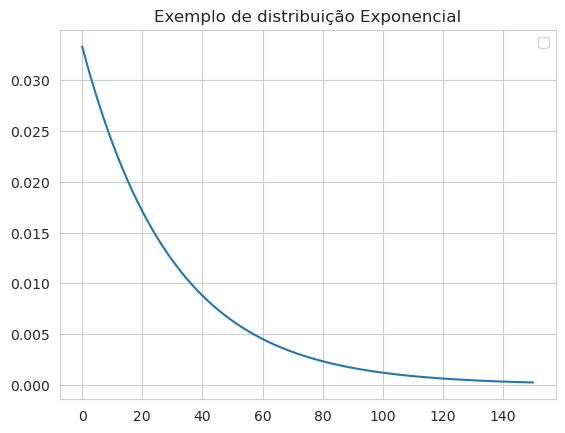

```python
def distribuicao_exponencial(valores, beta):
    y = []
    for valor in valores:
        resultado = (1/beta) * (np.exp(-(valor/beta)))
        y.append(resultado)
    return y

x = list(np.linspace(0, 150, 1000))
y = distribuicao_exponencial(x, 30)

with sns.axes_style("whitegrid"):
    plt.plot(x, y)
    plt.legend()
    plt.title('Exemplo de distribuição Exponencial')
    plt.show()
```

Sua esperança matemática é:

$$E(X) = \beta$$$$Var(X) = \beta²$$

Sua função de densidade acumulada é:

$$f(x) = \begin{cases} 0, & \text{se } x < 0\\ 1 - e^{-\frac{x}{\beta}}, & \text{se }x \geq 0\\ \end{cases}$$

Vamos a um exemplo:

**Exemplo**: A média de um ciclo de vida de um videogame é de 10 anos. Qual a probabilidade que um videogame durar mais que a média?

$$P(X > 10) = \int_{10}^{+\infty}f(x)dx = \int_{10}^{+\infty}\frac{1}{\beta}e^{-\frac{x}{\beta}}$$$$P(X > 10) = \int_{10}^{+\infty}\frac{1}{10}e^{-\frac{x}{10}} = \frac{1}{10}\int_{10}^{+\infty}e^{-\frac{x}{10}}$$$$P(X > 10) = \frac{1}{10}\Big[\frac{1}{\frac{1}{10}}e^{-\frac{x}{10}}\Big]_{10}^{+\infty}$$$$P(X > 10) = \frac{1}{10}\Big[-10e^{-\frac{x}{10}}\Big]_{10}^{+\infty}$$$$P(X > 10) = \frac{1}{10}\cdot-10\cdot(e^{-\frac{+\infty}{10}} - e^{-\frac{10}{10}})$$$$P(X > 10) = -1\cdot(0 - e^{-1}) = 0,3678$$

Então a probabilidade de o valor do videogame durar mais do que o tempo de vida médio é de 36,78%.

## Distribuição gama

**Definição**: A variável aleatória contínua X, assumindo valores positivos, tem uma distribuição gama com parâmetros $\alpha > 0$ e $\beta > 0$, se sua função densidade de probabilidade for da por:

$$f(x, \alpha, \beta) = \begin{cases} \frac{1}{\Gamma(\alpha)\beta^{\alpha}}x^{\alpha - 1}e^{-\frac{x}{\beta}}, & \text{se } x > 0\\ 0, & \text{se }x < 0\\ \end{cases}$$

$\Gamma(\alpha)$ é a função gama, sua fórmula é dada por:

$$\Gamma(\alpha) = \int_{0}^{+\infty} e^{-x}x^{\alpha-1}dx, \alpha > 0$$

Sabendo que para todo $\alpha$ inteiro e positivo, temos:

$$\Gamma(\alpha) = (\alpha - 1)!$$

Quando a variável aleatória tiver uma distribuição gama, usaremos a seguinte notação:

$$X \sim \text{Gama}(\alpha, \beta)$$

Sua esperança matemática é dada por:

$$E(X) = \alpha\beta$$

A variância é:

$$\text{Var(X)} = \alpha\beta² $$

Seu gráfico é:

```python
def fatorial(x):
    valor = 1
    for i in range(1, x+1):
        valor *= i
    return valor
```

[figure not shown]

```python
def distribuicao_gama(valores, alfa, beta):
    y = []
    for valor in valores:
        if valor > 0:
            resultado = (1/(fatorial(alfa-1) * (beta**alfa)))  * (valor**(alfa - 1) * np.exp(-(valor/beta)))
            y.append(resultado)
        else:
            resultado = 0
            y.append(resultado)
    return y

x1 = list(np.linspace(0, 30, 1000))
y1 = distribuicao_gama(x, 3, 1)
x2 = list(np.linspace(0, 30, 1000))
y2 = distribuicao_gama(x, 2, 1)
x3 = list(np.linspace(0, 30, 1000))
y3 = distribuicao_gama(x, 1, 1)
x4 = list(np.linspace(0, 30, 1000))
y4 = distribuicao_gama(x, 4, 1)
x5 = list(np.linspace(0, 30, 1000))
y5 = distribuicao_gama(x, 5, 1)
with sns.axes_style("whitegrid"):
    plt.plot(x1, y1, label='$𝛼=1, 𝛽=1$')
    plt.plot(x2, y2, label='$𝛼=2, 𝛽=1$')
    plt.plot(x3, y3, label='$𝛼=3, 𝛽=1$')
    plt.plot(x4, y4, label='$𝛼=4, 𝛽=1$')
    plt.plot(x5, y5, label='$𝛼=5, 𝛽=2$')
    plt.legend()
    plt.title('Exemplo de distribuição Gama')
    plt.show()
```

# Distribuição Qui-Quadrado

É um caso especial do modelo gama. Essa distribuição é obtida fazendo com que $\alpha = \frac{v}{2}$ e $\beta = 2$, com $v > 0$ e inteiro.

**Definição**: Uma variável aleatória contínua X, com valores positivos, tem uma distribuição qui-quadrado com $v$ graus de liberdade, se sua função densidade de probabilidade for dada por:

$$f(x, v) = \begin{cases} \frac{1}{\Gamma(\frac{v}{2})2^{\frac{v}{2}}}x^{\frac{v}{2} - 1}e^{-\frac{x}{2}}, & \text{se } x > 0\\ 0, & \text{se }x < 0\\ \end{cases}$$

Quando a variável aleatória tiver uma distribuição qui-quadrado, usaremos a seguinte notação:

$$X \sim \chi²(v)$$

Sua esperança matemática é dada por:

$$E(X) = v$$

A variância é:

$$\text{Var(X)} = 2v $$

A distribuição qui-quadrado possui diversas aplicações e como a distribuição normal, já possui uma tabela com as probabilidades calculadas.

[figure not shown]

Seu gráfico é:

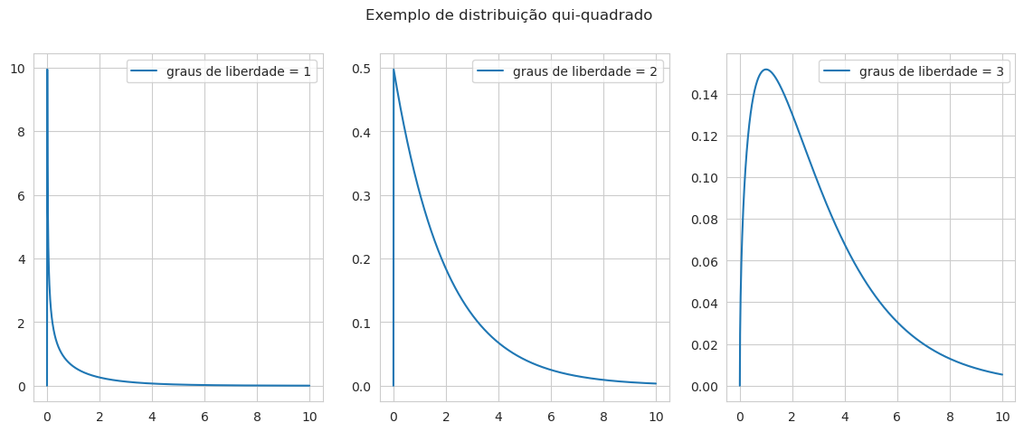

```python
def distribuicao_qui_quadrado(valores, graus_liberdade):
    y = []
    for valor in valores:
        if valor > 0:
            resultado = (1/(fatorial((int(graus_liberdade/2)) -1 ) * (2**graus_liberdade/2)))  * (valor**(graus_liberdade/2 - 1) * np.exp(-(valor/2)))
            y.append(resultado)
        else:
            resultado = 0
            y.append(resultado)
    return y

x = list(np.linspace(0, 10, 1000))
y1 = distribuicao_qui_quadrado(x, 1)
y2 = distribuicao_qui_quadrado(x, 2)
y3 = distribuicao_qui_quadrado(x, 3)
with sns.axes_style("whitegrid"):
    plt.figure(figsize=(14, 5))
    plt.suptitle('Exemplo de distribuição qui-quadrado')
    ax1 = plt.subplot(1, 3, 1)
    ax2 = plt.subplot(1, 3, 2)
    ax3 = plt.subplot(1, 3, 3)
    ax1.plot(x, y1, label='graus de liberdade = 1')
    ax2.plot(x, y2, label='graus de liberdade = 2')
    ax3.plot(x, y3, label='graus de liberdade = 3')
    ax1.legend()
    ax2.legend()
    ax3.legend()
    plt.show()
```

## Distribuição t de Student

Essa distribuição é importante para a parte de inferências sobre médias populacionais.

Sua definição é:

**Definição**:

Seja X uma variável aleatória de distribuição normal padrão ($N(0, 1)$) e Y uma variável aleatória de distribuição qui-quadrado ($\chi²(v)$).

$$t = \frac{X}{\sqrt{\frac{Y}{v}}}$$

sua densidade é dada por:

$$f(t, v) = \frac{\Gamma(\frac{v+1}{2})}{\Gamma(\frac{v}{2})\sqrt{\pi v}} \cdot (1 + \frac{t²}{v})^{-\frac{v+1}{2}}, -\infty < t < +\infty$$

Diremos que tal variável tem uma distribuição $t$ de Student com $v$ graus de liberdade e indicaremos por $t(v)$.

A esperança matemática é:

$$E(t) = 0$$

E a variância é:

$$\text{Var(t)} = \frac{v}{v-2}, v > 2$$

Seu gráfico é:

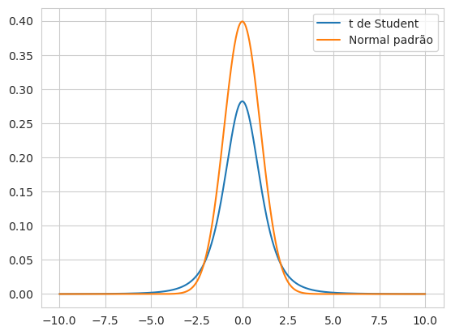

```python
def distribuicao_t_student(valores, graus_liberdade):
    y = []
    for valor in valores:
        parte1 = (fatorial(int(((graus_liberdade + 1)/2)-1))) / (fatorial((int(graus_liberdade /2)-1)) * (np.sqrt((np.pi*graus_liberdade))))
        parte2 = (1 + ((valor**2)/graus_liberdade))**(-((graus_liberdade + 1)/2))
        resultado =  parte1 * parte2
        y.append(resultado)
    return y

x1 = list(np.linspace(-10, 10, 1000))
y1 = distribuicao_t_student(x1, 4)
y2 = distribuicao_normal_padronizada(x1)
with sns.axes_style("whitegrid"):
    plt.plot(x1, y1, label='t de Student')
    plt.plot(x1, y2, label='Normal padrão')
    plt.legend()
    plt.show()
```

## Distribuição F de Snedecor

Essa distribuição é utilizada na análise de variâncias (ANOVA). Sua definição é:

**Definição**: Sejam X e Y duas variáveis aleatórias independentes, cada uma com distribuição qui-quadrado, com $v_1$ e $v_2$ graus de liberdade, respectivamente. Então a variável aleatória é:

$$W = \frac{\frac{X}{v_1}}{\frac{Y}{v_2}}$$

Tem densidade dada por:

$$f(w, v_1, v_2) = \frac{\Gamma(\frac{v_1 + v_2}{2})}{\Gamma(\frac{v_1}{2})\Gamma(\frac{v_2}{2})}\Big(\frac{v_1}{v_2}\Big)^{\frac{v_1}{2}} \frac{w^{\frac{v_1 - 2}{2}}}{(1 + \frac{v_1w}{v_2})^{\frac{v_1 + v_2}{2}}}, w > 0$$

Quando a variável aleatória tiver uma distribuição F de Snedecor, usaremos a seguinte notação:

$$X \sim F(v_1, v_2)$$

Sua esperança matemática é:

$$E(X) = \frac{v_2}{v_2-2}$$

E a variância é:

$$\text{Var(X)} = \frac{2v_2^{2}\cdot(v_1 + v_2 - 2)}{v_1(v_2 - 2)² \cdot(v_2 - 4)}$$

Seu gráfico é:

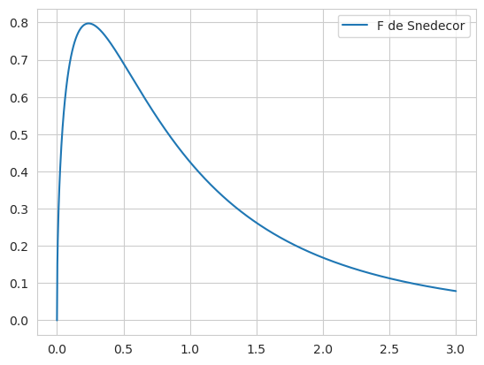

```python
def distribuicao_f_snedecor(valores, graus_liberdade_1, graus_liberdade_2):
    y = []
    for valor in valores:
        parte1 = (fatorial(int(((graus_liberdade_1 + graus_liberdade_2)/2)-1))) / (fatorial((int(graus_liberdade_1 /2)-1)) * fatorial((int(graus_liberdade_2 /2)-1)))
        parte2 = (graus_liberdade_1/graus_liberdade_2)**(graus_liberdade_1/2)
        parte3 = (valor**((graus_liberdade_1-2)/2)) / ((1 + (graus_liberdade_1*valor/graus_liberdade_2))**((graus_liberdade_1 + graus_liberdade_2)/2))
        resultado =  parte1 * parte2  * parte3
        y.append(resultado)
    return y

x1 = list(np.linspace(0, 3, 1000))
y1 = distribuicao_f_snedecor(x1, 3, 5)
with sns.axes_style("whitegrid"):
    plt.plot(x1, y1, label='F de Snedecor')
    plt.legend()
    plt.show()
```

# Referências

1. Morettin, P. A., Bussab, W. O. **Estatística Básica**, 6. ed. – São Paulo : Saraiva, 2010.
2. Bruce, P., Bruce, A., Gedeck, P. **Pratical Statistics for Data Scientists**, 2 ed. O'Reilly, 2020.

| [$\leftarrow$Ir para artigo anterior](https://fhfraga.github.io/pages/conceitos/estatistica/4_variaveis_aleatorias_discretas.html) | [Voltar ao site](https://fhfraga.github.io/) | [Voltar à página de estatística](https://fhfraga.github.io/pages/conceitos/estatistica/) | [Ir para próximo artigo $\rightarrow$](https://fhfraga.github.io/pages/conceitos/estatistica/6_variaveis_aleatorias_multidimensionais.html) |
| --- | --- | --- | --- |